# One-way sensitivity analysis

# Set up

This analysis varies target reference concentration, target-complex internalization rate (`kint`), and target degradation rate (`kdeg`) one parameter at a time. Each parameter is evaluated at 0.1- and 10-fold its a priori value for every configured monkey and human molecule-dose scenario. The already generated, unvaried scenario simulations are used as the 1-fold clearance reference; a 1-fold sensitivity simulation is not run.

```r
rm(list = ls())

library(tidyverse)
library(data.table)
library(scales)
library(knitr)
library(openxlsx)
library(kableExtra)
library(esqlabsR)

AUC_END_H <- 28 * 24
SPECIES_BW_KG <- c(Monkey = 3.5, Human = 70)
SA_FACTORS <- c(0.1, 10)
SA_PARAMETER_PATHS <- c(
  "Target reference concentration" = "Target|Reference concentration",
  "kint" = "Complex Internalization|kint",
  "kdeg" = "Target degradation|kdeg"
)
MAB_PLASMA_OUTPUT_PATH <-
  "Organism|PeripheralVenousBlood|mAb|Plasma (Peripheral Venous Blood)"
FORCE_RERUN_SA <- FALSE

results_dir <- "../SimsOutputs/SimulationResults"
sa_output_dir <- "../SimsOutputs/OneWaySensitivity"
figures_dir <- "../SimsOutputs/Figures"
dir.create(sa_output_dir, recursive = TRUE, showWarnings = FALSE)
dir.create(figures_dir, recursive = TRUE, showWarnings = FALSE)

parse_scenario <- function(path) {
  base <- tools::file_path_sans_ext(basename(path))
  base <- sub("_mpk$", "", base)
  parts <- strsplit(base, "_")[[1]]
  n <- length(parts)

  list(
    Molecule = paste(parts[seq_len(n - 2)], collapse = "_"),
    Species = parts[n - 1],
    Dose = suppressWarnings(as.numeric(parts[n]))
  )
}

mean_or_na <- function(x) {
  x <- x[is.finite(x)]
  if (length(x) == 0) NA_real_ else mean(x)
}

best_terminal_lambda_z <- function(time_h, conc, min_points = 3L) {
  terminal_data <- tibble(
    time_h = as.numeric(time_h),
    conc = as.numeric(conc)
  ) %>%
    filter(is.finite(time_h), is.finite(conc), conc > 0) %>%
    group_by(time_h) %>%
    summarise(conc = mean(conc), .groups = "drop") %>%
    arrange(time_h)

  if (nrow(terminal_data) < min_points) return(NA_real_)

  tmax_index <- which.max(terminal_data$conc)[1]
  post_cmax <- terminal_data %>% slice(seq.int(tmax_index, n()))
  if (nrow(post_cmax) < min_points) return(NA_real_)

  x <- post_cmax$time_h
  y <- log(post_cmax$conc)
  total_n <- length(x)
  suffix_sum <- function(z) rev(cumsum(rev(z)))
  sx <- suffix_sum(x)
  sy <- suffix_sum(y)
  sxx <- suffix_sum(x * x)
  syy <- suffix_sum(y * y)
  sxy <- suffix_sum(x * y)
  terminal_n <- seq.int(min_points, total_n)
  start_index <- total_n - terminal_n + 1L
  centered_xx <- sxx[start_index] - sx[start_index]^2 / terminal_n
  centered_yy <- syy[start_index] - sy[start_index]^2 / terminal_n
  centered_xy <-
    sxy[start_index] - sx[start_index] * sy[start_index] / terminal_n
  slope <- centered_xy / centered_xx
  r2 <- pmin(
    pmax((centered_xy^2) / (centered_xx * centered_yy), 0),
    1
  )
  adjusted_r2 <- 1 - (1 - r2) * (terminal_n - 1) / (terminal_n - 2)

  candidates <- tibble(slope, adjusted_r2, terminal_n) %>%
    filter(is.finite(slope), slope < 0, is.finite(adjusted_r2)) %>%
    arrange(desc(adjusted_r2), desc(terminal_n))

  if (nrow(candidates) == 0) NA_real_ else -candidates$slope[1]
}

auc_inf_ug_h_ml <- function(time_h, conc, lambda_z) {
  profile <- tibble(
    time_h = as.numeric(time_h),
    conc = as.numeric(conc)
  ) %>%
    filter(
      is.finite(time_h), is.finite(conc),
      time_h >= 0, time_h <= AUC_END_H, conc >= 0
    ) %>%
    group_by(time_h) %>%
    summarise(conc = mean(conc), .groups = "drop") %>%
    arrange(time_h)

  if (nrow(profile) == 0 || !any(profile$conc > 0) || !is.finite(lambda_z)) {
    return(NA_real_)
  }
  if (!any(profile$time_h == 0)) {
    profile <- bind_rows(tibble(time_h = 0, conc = 0), profile) %>%
      arrange(time_h)
  }

  positive <- profile %>% filter(conc > 0)
  last_index <- which.max(positive$time_h)
  c_last <- positive$conc[last_index]
  last_time <- positive$time_h[last_index]
  through_last <- profile %>% filter(time_h <= last_time)
  dt <- diff(through_last$time_h)
  c1 <- through_last$conc[-nrow(through_last)]
  c2 <- through_last$conc[-1]
  declining <- c2 < c1 & c1 > 0 & c2 > 0
  auc_last <- sum(ifelse(
    declining,
    dt * (c1 - c2) / log(c1 / c2),
    dt * (c1 + c2) / 2
  ))

  auc_last + c_last / lambda_z
}

terminal_clearance_l_day <- function(dose_mg_kg, body_weight_kg, auc_inf) {
  if (
    !is.finite(dose_mg_kg) || dose_mg_kg <= 0 ||
      !is.finite(body_weight_kg) || body_weight_kg <= 0 ||
      !is.finite(auc_inf) || auc_inf <= 0
  ) {
    return(NA_real_)
  }

  24 * dose_mg_kg * body_weight_kg / auc_inf
}

read_target_lookup <- function(files) {
  read_one_sheet <- function(file, sheet) {
    x <- openxlsx::read.xlsx(file, sheet = sheet, check.names = FALSE)
    names(x) <- trimws(names(x))
    normalized_names <- names(x) %>%
      tolower() %>%
      gsub("[^a-z0-9]+", " ", .) %>%
      trimws()
    molecule_col <- names(x)[match("drug name", normalized_names)]
    target_col <- names(x)[match("target name", normalized_names)]

    if (is.na(molecule_col) || is.na(target_col)) return(NULL)

    x %>%
      transmute(
        Molecule = trimws(as.character(.data[[molecule_col]])),
        Target = trimws(as.character(.data[[target_col]]))
      ) %>%
      filter(Molecule != "", Target != "") %>%
      distinct()
  }

  map_dfr(files, function(file) {
    map_dfr(openxlsx::getSheetNames(file), ~ read_one_sheet(file, .x))
  }) %>%
    distinct(Molecule, .keep_all = TRUE)
}

target_lookup <- read_target_lookup(c(
  "../../01_Data/Monkey/Parameters.xlsx",
  "../../01_Data/Human/Parameters_human.xlsx"
))

mw_lookup <- bind_rows(
  read.csv(
    "../../01_Data/Monkey/mAb_data_clean.csv",
    stringsAsFactors = FALSE,
    check.names = FALSE
  ) %>% distinct(Molecule, MW = Molecular.Weight),
  read.csv(
    "../../01_Data/Human/mAb_data_human.csv",
    stringsAsFactors = FALSE,
    check.names = FALSE
  ) %>% distinct(Molecule, MW = Molecular.Weight)
) %>%
  mutate(MW = as.numeric(MW)) %>%
  distinct(Molecule, .keep_all = TRUE)
```

# Unvaried clearance reference

Clearance for the 1-fold reference is calculated from the most recent set of previously generated scenario CSV files, using the same terminal-phase and AUC<sub>inf</sub> methods as the sensitivity simulations.

```r
simulation_result_folders <- list.dirs(
  results_dir,
  recursive = FALSE,
  full.names = TRUE
)
if (length(simulation_result_folders) == 0) {
  stop("No previously generated simulation result folders found in ", results_dir)
}

reference_results_dir <- simulation_result_folders[
  which.max(file.mtime(simulation_result_folders))
]
reference_csv_files <- list.files(
  reference_results_dir,
  pattern = "\\.csv$",
  full.names = TRUE
)
reference_csv_files <- reference_csv_files[
  !grepl("_population\\.csv$", reference_csv_files)
]

read_reference_clearance <- function(file) {
  meta <- parse_scenario(file)
  raw <- data.table::fread(file, data.table = FALSE)
  concentration_col <- grep(
    "PeripheralVenousBlood.*\\|mAb\\|.*Plasma.*\\[",
    names(raw),
    value = TRUE
  )[1]
  if (is.na(concentration_col)) {
    stop("mAb plasma concentration output not found in ", basename(file))
  }

  mw <- mw_lookup$MW[mw_lookup$Molecule == meta$Molecule][1]
  bw <- unname(SPECIES_BW_KG[meta$Species])
  if (!is.finite(mw) || !is.finite(bw)) {
    stop("Missing molecular weight or body weight for ", basename(file))
  }

  raw %>%
    transmute(
      IndividualId = as.integer(IndividualId),
      Time_h = as.numeric(`Time [min]`) / 60,
      Conc_ug_mL = as.numeric(.data[[concentration_col]]) * mw / 1000
    ) %>%
    group_by(IndividualId) %>%
    summarise(
      lambda_z = best_terminal_lambda_z(Time_h, Conc_ug_mL),
      AUCinf_ug_h_mL = auc_inf_ug_h_ml(Time_h, Conc_ug_mL, lambda_z),
      CL_L_day = terminal_clearance_l_day(meta$Dose, bw, AUCinf_ug_h_mL),
      .groups = "drop"
    ) %>%
    summarise(
      Scenario = tools::file_path_sans_ext(basename(file)),
      Molecule = meta$Molecule,
      Species = meta$Species,
      Dose = meta$Dose,
      Baseline_CL_L_day = mean_or_na(CL_L_day)
    )
}

reference_clearance <- map_dfr(
  reference_csv_files,
  read_reference_clearance
) %>%
  distinct(Scenario, .keep_all = TRUE)
```

# Run the one-way sensitivity simulations

Only the 0.1- and 10-fold conditions are simulated. In each run, one parameter is varied and all remaining parameters retain their a priori values.

```r
sa_scenarios <- openxlsx::read.xlsx(
  "../Configurations/Scenarios.xlsx",
  sheet = "Scenarios",
  check.names = FALSE
) %>%
  transmute(Scenario = as.character(Scenario_name)) %>%
  mutate(
    Meta = map(Scenario, ~ parse_scenario(paste0(.x, ".csv"))),
    Molecule = map_chr(Meta, "Molecule"),
    Species = map_chr(Meta, "Species"),
    Dose = map_dbl(Meta, "Dose")
  ) %>%
  select(-Meta) %>%
  filter(Species %in% c("Monkey", "Human")) %>%
  left_join(target_lookup, by = "Molecule") %>%
  arrange(Species, Target, Molecule, Dose)

missing_reference <- anti_join(
  sa_scenarios,
  reference_clearance,
  by = c("Scenario", "Molecule", "Species", "Dose")
)
if (nrow(missing_reference) > 0) {
  stop(
    "No unvaried reference simulation was found for: ",
    paste(missing_reference$Scenario, collapse = ", ")
  )
}

project_configuration <- createProjectConfiguration(
  "../ProjectConfiguration.xlsx"
)
sa_run_options <- ospsuite::SimulationRunOptions$new()
sa_run_options$checkForNegativeValues <- FALSE
sa_run_options$numberOfCores <- min(
  8L,
  max(1L, parallel::detectCores() - 1L)
)

run_sa_scenario <- function(scenario_name, molecule, species, dose) {
  cache_file <- file.path(sa_output_dir, paste0(scenario_name, ".csv"))

  if (file.exists(cache_file) && !FORCE_RERUN_SA) {
    cached <- read.csv(
      cache_file,
      stringsAsFactors = FALSE,
      check.names = FALSE
    )
    cache_complete <- all(c(
      "Scenario", "Molecule", "Species", "Dose", "Parameter",
      "VariationFactor", "ParameterValue", "ParameterUnit", "Pred_CL_L_day"
    ) %in% names(cached)) &&
      setequal(cached$Parameter, names(SA_PARAMETER_PATHS)) &&
      setequal(round(cached$VariationFactor, 10), round(SA_FACTORS, 10)) &&
      nrow(cached) == length(SA_PARAMETER_PATHS) * length(SA_FACTORS)

    if (cache_complete) return(as_tibble(cached))
  }

  mw <- mw_lookup$MW[mw_lookup$Molecule == molecule][1]
  bw <- unname(SPECIES_BW_KG[species])
  if (!is.finite(mw) || !is.finite(bw)) {
    stop("Missing molecular weight or body weight for ", scenario_name)
  }

  scenario_configuration <- readScenarioConfigurationFromExcel(
    scenarioNames = scenario_name,
    projectConfiguration = project_configuration
  )
  scenario <- createScenarios(
    scenarioConfigurations = scenario_configuration
  )[[scenario_name]]

  terminal_cl <- function(x, y) {
    time_h <- as.numeric(x) / 60
    conc_ug_ml <- as.numeric(y) * mw / 1000
    lambda_z <- best_terminal_lambda_z(time_h, conc_ug_ml)
    auc_inf <- auc_inf_ug_h_ml(time_h, conc_ug_ml, lambda_z)
    terminal_clearance_l_day(dose, bw, auc_inf)
  }

  # sensitivityCalculation() always inserts a 1-fold run into each parameter
  # range. Build the batches directly so that only 0.1- and 10-fold simulations
  # are run; the existing scenario result remains the sole 1-fold reference.
  simulation <- scenario$simulation
  old_output_paths <- map_chr(
    simulation$outputSelections$allOutputs,
    "path"
  )
  clearOutputs(simulation = simulation)
  addOutputs(
    quantitiesOrPaths = MAB_PLASMA_OUTPUT_PATH,
    simulation = simulation
  )

  parameter_paths <- unname(SA_PARAMETER_PATHS)
  initial_values <- set_names(
    map_dbl(
      parameter_paths,
      ~ as.numeric(getQuantityValuesByPath(
        quantityPaths = .x,
        simulation = simulation
      ))
    ),
    parameter_paths
  )
  parameter_units <- set_names(
    map_chr(parameter_paths, function(parameter_path) {
      matched <- getAllParametersMatching(
        paths = parameter_path,
        container = simulation
      )
      if (length(matched) != 1) {
        stop(
          "Expected one match for ", parameter_path, " in ", scenario_name,
          "; found ", length(matched)
        )
      }
      as.character(matched[[1]]$unit)
    }),
    parameter_paths
  )

  is_formula <- map_lgl(
    parameter_paths,
    ~ isExplicitFormulaByPath(path = .x, simulation = simulation)
  )
  constant_paths <- parameter_paths[!is_formula]
  formula_paths <- parameter_paths[is_formula]
  result_id_map <- set_names(
    map(parameter_paths, ~ set_names(vector("list", length(SA_FACTORS)),
                                    as.character(SA_FACTORS))),
    parameter_paths
  )
  simulation_batches <- list()

  if (length(constant_paths) > 0) {
    constant_batch <- createSimulationBatch(
      simulation = simulation,
      parametersOrPaths = constant_paths
    )
    for (parameter_path in constant_paths) {
      for (variation_factor in SA_FACTORS) {
        run_values <- initial_values[constant_paths]
        run_values[[parameter_path]] <-
          initial_values[[parameter_path]] * variation_factor
        result_id_map[[parameter_path]][[as.character(variation_factor)]] <-
          constant_batch$addRunValues(parameterValues = run_values)
      }
    }
    simulation_batches <- c(simulation_batches, constant_batch)
  }

  for (parameter_path in formula_paths) {
    formula_batch <- createSimulationBatch(
      simulation = simulation,
      parametersOrPaths = parameter_path
    )
    for (variation_factor in SA_FACTORS) {
      result_id_map[[parameter_path]][[as.character(variation_factor)]] <-
        formula_batch$addRunValues(
          parameterValues =
            initial_values[[parameter_path]] * variation_factor
        )
    }
    simulation_batches <- c(simulation_batches, formula_batch)
  }

  batch_results <- runSimulationBatches(
    simulationBatches = simulation_batches,
    simulationRunOptions = sa_run_options,
    stopIfFails = FALSE
  )
  names(batch_results) <- NULL
  batch_results <- unlist(batch_results)

  result <- map_dfr(parameter_paths, function(parameter_path) {
    parameter_label <- names(SA_PARAMETER_PATHS)[
      match(parameter_path, SA_PARAMETER_PATHS)
    ]

    map_dfr(SA_FACTORS, function(variation_factor) {
      result_id <-
        result_id_map[[parameter_path]][[as.character(variation_factor)]]
      simulation_result <- purrr::pluck(batch_results, result_id)
      if (is.null(simulation_result)) {
        stop(
          "Sensitivity simulation failed for ", scenario_name, ": ",
          parameter_label, " at ", variation_factor, "-fold"
        )
      }

      output <- simulationResultsToDataFrame(simulation_result) %>%
        filter(paths == MAB_PLASMA_OUTPUT_PATH)
      if (nrow(output) == 0) {
        stop(
          "Sensitivity output was not found for ", scenario_name, ": ",
          parameter_label, " at ", variation_factor, "-fold"
        )
      }

      tibble(
        Scenario = scenario_name,
        Molecule = molecule,
        Species = species,
        Dose = dose,
        Parameter = parameter_label,
        VariationFactor = variation_factor,
        ParameterValue =
          initial_values[[parameter_path]] * variation_factor,
        ParameterUnit = parameter_units[[parameter_path]],
        Pred_CL_L_day = terminal_cl(
          output$Time,
          output$simulationValues
        )
      )
    })
  }) %>%
    arrange(Parameter, VariationFactor)

  expected_runs <- tidyr::crossing(
    Parameter = names(SA_PARAMETER_PATHS),
    VariationFactor = SA_FACTORS
  )
  missing_runs <- anti_join(
    expected_runs,
    result,
    by = c("Parameter", "VariationFactor")
  )
  if (nrow(missing_runs) > 0 || any(!is.finite(result$Pred_CL_L_day))) {
    stop(
      "Incomplete sensitivity results for ", scenario_name,
      ". Expected exactly the 0.1- and 10-fold runs for all three parameters."
    )
  }

  write.csv(result, cache_file, row.names = FALSE, na = "")
  clearOutputs(simulation = simulation)
  walk(
    old_output_paths,
    ~ addOutputs(quantitiesOrPaths = .x, simulation = simulation)
  )
  ospsuite::clearMemory()
  result
}

sa_results <- pmap_dfr(
  sa_scenarios %>% select(Scenario, Molecule, Species, Dose),
  function(Scenario, Molecule, Species, Dose) {
    message("One-way sensitivity analysis: ", Scenario)
    run_sa_scenario(Scenario, Molecule, Species, Dose)
  }
)
```

# Clearance change from the unvaried simulations

Percent delta in terminal clearance is calculated as `100 * (varied clearance / unvaried clearance - 1)`. The normalized sensitivity coefficient is `log(varied clearance / unvaried clearance) / log(variation factor)`. For display, 1 is added to this coefficient so that no sensitivity is centered at 1.

```r
sa_change_table <- sa_results %>%
  left_join(
    reference_clearance,
    by = c("Scenario", "Molecule", "Species", "Dose")
  ) %>%
  left_join(target_lookup, by = "Molecule") %>%
  mutate(
    CL_Percent_Delta =
      100 * (Pred_CL_L_day / Baseline_CL_L_day - 1),
    Normalized_Sensitivity_Coefficient =
      log(Pred_CL_L_day / Baseline_CL_L_day) / log(VariationFactor),
    # Shift the conventional coefficient by 1 so that no sensitivity is
    # centered at 1 rather than 0.
    Normalized_Sensitivity_Index =
      1 + Normalized_Sensitivity_Coefficient
  ) %>%
  transmute(
    Species,
    Target,
    Molecule,
    `Dose (mg/kg)` = Dose,
    `Parameter varied` = Parameter,
    `Variation (fold)` = VariationFactor,
    `Varied parameter value` = ParameterValue,
    `Parameter unit` = ParameterUnit,
    `Reference terminal CL (L/day)` = Baseline_CL_L_day,
    `Varied terminal CL (L/day)` = Pred_CL_L_day,
    `Delta terminal CL (%)` = CL_Percent_Delta,
    `Normalized sensitivity coefficient` =
      Normalized_Sensitivity_Coefficient,
    `Normalized sensitivity index (no sensitivity = 1)` =
      Normalized_Sensitivity_Index
  ) %>%
  arrange(
    Species,
    Target,
    Molecule,
    `Dose (mg/kg)`,
    `Parameter varied`,
    `Variation (fold)`
  )

sa_tornado_table <- sa_change_table %>%
  group_by(
    Species,
    Target,
    Molecule,
    `Parameter varied`,
    `Variation (fold)`
  ) %>%
  summarise(
    `Mean delta terminal CL (%)` =
      mean_or_na(`Delta terminal CL (%)`),
    `Mean normalized sensitivity coefficient` =
      mean_or_na(`Normalized sensitivity coefficient`),
    `Mean normalized sensitivity index (no sensitivity = 1)` =
      1 + `Mean normalized sensitivity coefficient`,
    `Doses averaged (n)` = sum(is.finite(`Delta terminal CL (%)`)),
    .groups = "drop"
  )

write.csv(
  sa_change_table,
  file.path(sa_output_dir, "One_Way_Sensitivity_CL_Percent_Delta.csv"),
  row.names = FALSE,
  na = ""
)
write.csv(
  sa_tornado_table,
  file.path(sa_output_dir, "One_Way_Sensitivity_Mean_CL_Percent_Delta.csv"),
  row.names = FALSE,
  na = ""
)

sa_change_table %>%
  mutate(across(where(is.numeric), ~ round(.x, 4))) %>%
  kbl(
    caption = paste(
      "One-way sensitivity analysis by species, molecule, dose, parameter,",
      "and variation. Delta clearance is relative to the previously generated",
      "unvaried simulation."
    ),
    align = c("l", "l", "l", "r", "l", rep("r", 2), "l", rep("r", 5))
  ) %>%
  kable_styling(
    bootstrap_options = c("striped", "hover", "condensed"),
    full_width = TRUE,
    font_size = 10
  ) %>%
  scroll_box(height = "600px")
```

One-way sensitivity analysis by species, molecule, dose, parameter, and variation. Delta clearance is relative to the previously generated unvaried simulation.

| Species | Target | Molecule | Dose (mg/kg) | Parameter varied | Variation (fold) | Varied parameter value | Parameter unit | Reference terminal CL (L/day) | Varied terminal CL (L/day) | Delta terminal CL (%) | Normalized sensitivity coefficient | Normalized sensitivity index (no sensitivity = 1) |
| --- | --- | --- | --- | --- | --- | --- | --- | --- | --- | --- | --- | --- |
| Human | IL-6R | Tocilizumab | 8.0 | Target reference concentration | 0.1 | 0.0001 | µmol/l | 0.6905 | 0.2920 | -57.7084 | 0.3737 | 1.3737 |
| Human | IL-6R | Tocilizumab | 8.0 | Target reference concentration | 10.0 | 0.0100 | µmol/l | 0.6905 | 1.4127 | 104.5977 | 0.3109 | 1.3109 |
| Human | IL-6R | Tocilizumab | 8.0 | kdeg | 0.1 | 0.0005 | 1/min | 0.6905 | 0.2960 | -57.1342 | 0.3679 | 1.3679 |
| Human | IL-6R | Tocilizumab | 8.0 | kdeg | 10.0 | 0.0467 | 1/min | 0.6905 | 1.3093 | 89.6263 | 0.2779 | 1.2779 |
| Human | IL-6R | Tocilizumab | 8.0 | kint | 0.1 | 0.0005 | 1/min | 0.6905 | 0.6332 | -8.2987 | 0.0376 | 1.0376 |
| Human | IL-6R | Tocilizumab | 8.0 | kint | 10.0 | 0.0467 | 1/min | 0.6905 | 0.6996 | 1.3203 | 0.0057 | 1.0057 |
| Human | PD-1 | Nivolumab | 1.0 | Target reference concentration | 0.1 | 0.0000 | µmol/l | 0.2308 | 0.2308 | -0.0003 | 0.0000 | 1.0000 |
| Human | PD-1 | Nivolumab | 1.0 | Target reference concentration | 10.0 | 0.0007 | µmol/l | 0.2308 | 0.2308 | -0.0003 | 0.0000 | 1.0000 |
| Human | PD-1 | Nivolumab | 1.0 | kdeg | 0.1 | 0.0000 | 1/min | 0.2308 | 0.2308 | -0.0003 | 0.0000 | 1.0000 |
| Human | PD-1 | Nivolumab | 1.0 | kdeg | 10.0 | 0.0045 | 1/min | 0.2308 | 0.2308 | -0.0003 | 0.0000 | 1.0000 |
| Human | PD-1 | Nivolumab | 1.0 | kint | 0.1 | 0.0000 | 1/min | 0.2308 | 0.2308 | -0.0003 | 0.0000 | 1.0000 |
| Human | PD-1 | Nivolumab | 1.0 | kint | 10.0 | 0.0045 | 1/min | 0.2308 | 0.2308 | -0.0003 | 0.0000 | 1.0000 |
| Human | PD-1 | Nivolumab | 3.0 | Target reference concentration | 0.1 | 0.0000 | µmol/l | 0.2312 | 0.2312 | 0.0002 | 0.0000 | 1.0000 |
| Human | PD-1 | Nivolumab | 3.0 | Target reference concentration | 10.0 | 0.0007 | µmol/l | 0.2312 | 0.2312 | 0.0002 | 0.0000 | 1.0000 |
| Human | PD-1 | Nivolumab | 3.0 | kdeg | 0.1 | 0.0000 | 1/min | 0.2312 | 0.2312 | 0.0002 | 0.0000 | 1.0000 |
| Human | PD-1 | Nivolumab | 3.0 | kdeg | 10.0 | 0.0045 | 1/min | 0.2312 | 0.2312 | 0.0002 | 0.0000 | 1.0000 |
| Human | PD-1 | Nivolumab | 3.0 | kint | 0.1 | 0.0000 | 1/min | 0.2312 | 0.2312 | 0.0002 | 0.0000 | 1.0000 |
| Human | PD-1 | Nivolumab | 3.0 | kint | 10.0 | 0.0045 | 1/min | 0.2312 | 0.2312 | 0.0002 | 0.0000 | 1.0000 |
| Human | PD-1 | Nivolumab | 4.0 | Target reference concentration | 0.1 | 0.0000 | µmol/l | 0.2314 | 0.2314 | 0.0000 | 0.0000 | 1.0000 |
| Human | PD-1 | Nivolumab | 4.0 | Target reference concentration | 10.0 | 0.0007 | µmol/l | 0.2314 | 0.2314 | 0.0000 | 0.0000 | 1.0000 |
| Human | PD-1 | Nivolumab | 4.0 | kdeg | 0.1 | 0.0000 | 1/min | 0.2314 | 0.2314 | 0.0000 | 0.0000 | 1.0000 |
| Human | PD-1 | Nivolumab | 4.0 | kdeg | 10.0 | 0.0045 | 1/min | 0.2314 | 0.2314 | 0.0000 | 0.0000 | 1.0000 |
| Human | PD-1 | Nivolumab | 4.0 | kint | 0.1 | 0.0000 | 1/min | 0.2314 | 0.2314 | 0.0000 | 0.0000 | 1.0000 |
| Human | PD-1 | Nivolumab | 4.0 | kint | 10.0 | 0.0045 | 1/min | 0.2314 | 0.2314 | 0.0000 | 0.0000 | 1.0000 |
| Human | PD-1 | Nivolumab | 6.0 | Target reference concentration | 0.1 | 0.0000 | µmol/l | 0.2318 | 0.2318 | 0.0000 | 0.0000 | 1.0000 |
| Human | PD-1 | Nivolumab | 6.0 | Target reference concentration | 10.0 | 0.0007 | µmol/l | 0.2318 | 0.2318 | 0.0000 | 0.0000 | 1.0000 |
| Human | PD-1 | Nivolumab | 6.0 | kdeg | 0.1 | 0.0000 | 1/min | 0.2318 | 0.2318 | 0.0000 | 0.0000 | 1.0000 |
| Human | PD-1 | Nivolumab | 6.0 | kdeg | 10.0 | 0.0045 | 1/min | 0.2318 | 0.2318 | 0.0000 | 0.0000 | 1.0000 |
| Human | PD-1 | Nivolumab | 6.0 | kint | 0.1 | 0.0000 | 1/min | 0.2318 | 0.2318 | 0.0000 | 0.0000 | 1.0000 |
| Human | PD-1 | Nivolumab | 6.0 | kint | 10.0 | 0.0045 | 1/min | 0.2318 | 0.2318 | 0.0000 | 0.0000 | 1.0000 |

[output cut: 234 more lines]

# Tornado plot

Bars show the mean normalized sensitivity index across doses for each molecule, species, parameter, and variation. An index of 1 indicates no sensitivity; distance from 1 indicates increasing sensitivity.

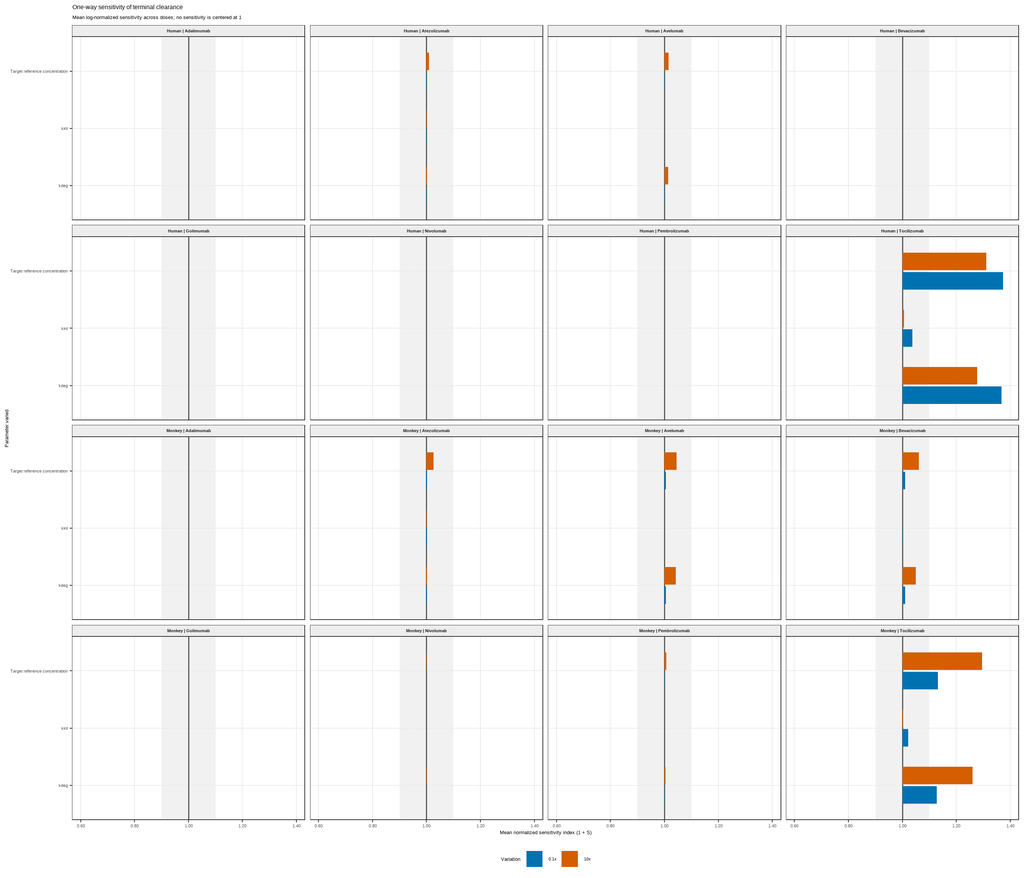

```r
parameter_levels <- rev(names(SA_PARAMETER_PATHS))

sa_tornado_plot_data <- sa_tornado_table %>%
  mutate(
    `Parameter varied` = factor(
      `Parameter varied`,
      levels = parameter_levels
    ),
    `Variation (fold)` = factor(
      `Variation (fold)`,
      levels = SA_FACTORS,
      labels = paste0(SA_FACTORS, "x")
    ),
    `Normalized index deviation` =
      `Mean normalized sensitivity index (no sensitivity = 1)` - 1,
    Panel = paste(Species, Molecule, sep = " | ")
  )

maximum_index_deviation <- max(
  abs(
    sa_tornado_plot_data[[
      "Mean normalized sensitivity index (no sensitivity = 1)"
    ]] - 1
  ),
  na.rm = TRUE
)
if (!is.finite(maximum_index_deviation) || maximum_index_deviation == 0) {
  maximum_index_deviation <- 0.1
}

sa_tornado_plot <- sa_tornado_plot_data %>%
  ggplot(
    aes(
      x = `Normalized index deviation`,
      y = `Parameter varied`,
      fill = `Variation (fold)`
    )
  ) +
  annotate(
    "rect",
    xmin = -0.1,
    xmax = 0.1,
    ymin = -Inf,
    ymax = Inf,
    fill = "grey92",
    alpha = 0.7
  ) +
  geom_vline(xintercept = 0, colour = "grey35", linewidth = 0.55) +
  geom_col(
    position = position_dodge2(width = 0.8, preserve = "single"),
    width = 0.68
  ) +
  facet_wrap(~ Panel, ncol = 4) +
  scale_fill_manual(values = c("0.1x" = "#0072B2", "10x" = "#D55E00")) +
  scale_x_continuous(
    limits = c(-1, 1) * maximum_index_deviation * 1.05,
    labels = function(x) label_number(accuracy = 0.01)(x + 1)
  ) +
  labs(
    title = "One-way sensitivity of terminal clearance",
    subtitle = paste(
      "Mean log-normalized sensitivity across doses;",
      "no sensitivity is centered at 1"
    ),
    x = "Mean normalized sensitivity index (1 + S)",
    y = "Parameter varied",
    fill = "Variation"
  ) +
  theme_bw(base_size = 10) +
  theme(
    strip.background = element_rect(fill = "grey93"),
    strip.text = element_text(face = "bold", size = 8),
    legend.position = "bottom",
    panel.grid.minor = element_blank()
  )

tornado_plot_file <- file.path(
  figures_dir,
  "One_Way_Sensitivity_Tornado_Normalized_Index.png"
)
ggsave(
  tornado_plot_file,
  sa_tornado_plot,
  width = 14,
  height = 12,
  dpi = 300
)
sa_tornado_plot
```

# Export tables

```r
workbook <- createWorkbook()

addWorksheet(workbook, "Dose_Level_CL_Delta")
writeData(workbook, "Dose_Level_CL_Delta", sa_change_table)
setColWidths(
  workbook,
  "Dose_Level_CL_Delta",
  cols = seq_len(ncol(sa_change_table)),
  widths = "auto"
)

addWorksheet(workbook, "Mean_CL_Delta")
writeData(workbook, "Mean_CL_Delta", sa_tornado_table)
setColWidths(
  workbook,
  "Mean_CL_Delta",
  cols = seq_len(ncol(sa_tornado_table)),
  widths = "auto"
)

sensitivity_workbook <- file.path(
  sa_output_dir,
  "One_Way_Sensitivity_Analysis.xlsx"
)
saveWorkbook(workbook, sensitivity_workbook, overwrite = TRUE)
message("Saved: ", sensitivity_workbook)
```